# Final Project - Arizona OASDI Number of People Receiving Benefits and the Amount of Monthly Benefits (in thousands)

Rachel Young

February 26th 2020

## Introduction

Many people qualify for Social Security throughout the United States. This project will utilize the dataset that was taken from data.world based on the “Annual report providing Social Security beneficiary population data by state and ZIP code. Report for 2015”. The project will use various graphs and data tables to show how the data can be split up by ZIP code, County, City/Town, Number of Qualified Recipients, and Amount of Monthly Benefits (in thousands). This will help answer whether there is a correlation between the Total Monthly Benefits and Total Number of Recipients. It will also help answer questions about which Counties have the least and most amount of Total Monthly Benfits and Total Number of Recipients. There were multiple datasets for all the U.S. but I only used the Arizona dataset.

## Preparation

The following R libraries will be used:  
- library(readxl)  
- library(dplyr)  
- library(ggplot2)  
- library(car)  
- library(pastecs)

## Dataset

```r
library(readxl)
library(dplyr)
```

```r
library(ggplot2)
library(car)
library(pastecs)
## Upload the data
oasdiData <- read_excel("~/Desktop/DSC520/Week10/updateoasdi_zip15.xlsx")

## Add TotalMonthlyBenefits to oasdiDataSummary
oasdiData$TotalMonthlyBenefits <- (oasdiData$AllBeneficiariesTotMonthlyBenefits + oasdiData$RetiredWorkersTotMonthlyBenefits + oasdiData$WidowsWidowersParentsTotMonthlyBenefits)

str(oasdiData)
```

```
## Classes 'tbl_df', 'tbl' and 'data.frame':    494 obs. of  14 variables:
##  $ ZIPcode                                : num  85001 85002 85003 85004 85005 ...
##  $ CityTown                               : chr  "Phoenix" "Phoenix" "Phoenix" "Phoenix" ...
##  $ County                                 : chr  "Maricopa" "Maricopa" "Maricopa" "Maricopa" ...
##  $ TotalNbr                               : num  805 100 1180 1305 215 ...
##  $ RetiredWorkersNbr                      : num  140 70 735 655 90 ...
##  $ DisabledWorkersNbr                     : num  410 20 270 330 55 ...
##  $ WidowsWidowersParentsNbr               : num  5 5 60 70 10 160 110 280 365 5 ...
##  $ SpousesNbr                             : num  5 0 40 25 5 80 60 165 245 0 ...
##  $ ChildrenNbr                            : num  245 5 75 225 55 235 220 435 480 10 ...
##  $ AllBeneficiariesTotMonthlyBenefits     : num  648 113 1379 1406 197 ...
##  $ RetiredWorkersTotMonthlyBenefits       : num  145 79 955 836 110 ...
##  $ WidowsWidowersParentsTotMonthlyBenefits: num  10 4 68 81 10 166 110 320 374 6 ...
##  $ NbrOfOASDIbeneficiariesAged65orOlder   : num  155 65 750 725 105 ...
##  $ TotalMonthlyBenefits                   : num  803 196 2402 2323 317 ...
```

The data was summarized for each field by County and was calculated based on the oasdiData table as shown below.

```r
## Summary of oasdiData
oasdiDataSummary <- oasdiData %>%
select(TotalNbr, RetiredWorkersNbr, DisabledWorkersNbr, WidowsWidowersParentsNbr, SpousesNbr, ChildrenNbr, AllBeneficiariesTotMonthlyBenefits, RetiredWorkersTotMonthlyBenefits, WidowsWidowersParentsTotMonthlyBenefits, NbrOfOASDIbeneficiariesAged65orOlder, TotalMonthlyBenefits) %>%
group_by(oasdiData$County) %>%
summarise(TotalNbr = sum(TotalNbr), RetiredWorkersNbr = sum(RetiredWorkersNbr), DisabledWorkersNbr = sum(DisabledWorkersNbr), WidowsWidowersParentsNbr = sum(WidowsWidowersParentsNbr), SpousesNbr = sum(SpousesNbr), ChildrenNbr = sum(ChildrenNbr), AllBeneficiariesTotMonthlyBenefits = sum(AllBeneficiariesTotMonthlyBenefits), RetiredWorkersTotMonthlyBenefits = sum(RetiredWorkersTotMonthlyBenefits), WidowsWidowersParentsTotMonthlyBenefits = sum(WidowsWidowersParentsTotMonthlyBenefits), NbrOfOASDIbeneficiariesAged65orOlder = sum(NbrOfOASDIbeneficiariesAged65orOlder), TotalMonthlyBenefits = sum(TotalMonthlyBenefits))

oasdiDataSummary
```

| oasdiData$County | TotalNbr | RetiredWorkersNbr | DisabledWorkersNbr | WidowsWidowersParentsNbr | SpousesNbr | ChildrenNbr | AllBeneficiariesTotMonthlyBenefits | RetiredWorkersTotMonthlyBenefits | WidowsWidowersParentsTotMonthlyBenefits | NbrOfOASDIbeneficiariesAged65orOlder | TotalMonthlyBenefits |
| --- | --- | --- | --- | --- | --- | --- | --- | --- | --- | --- | --- |
| Apache | 12400 | 7355 | 1725 | 1055 | 555 | 1710 | 12186 | 8258 | 919 | 8095 | 21363 |
| Cochise | 31300 | 22050 | 3810 | 2170 | 1575 | 1695 | 35203 | 26437 | 2476 | 23385 | 64116 |
| Coconino | 18250 | 12470 | 2420 | 1130 | 645 | 1585 | 21819 | 16332 | 1296 | 12790 | 39447 |
| Gila | 16615 | 11895 | 2115 | 1085 | 615 | 905 | 20782 | 15889 | 1375 | 12465 | 38046 |
| Graham | 6090 | 3755 | 870 | 510 | 335 | 620 | 7031 | 4807 | 619 | 4190 | 12457 |
| Greenlee | 1470 | 895 | 185 | 150 | 90 | 150 | 1780 | 1174 | 193 | 1020 | 3147 |
| La Paz | 5560 | 4115 | 650 | 370 | 175 | 250 | 6302 | 4909 | 414 | 4290 | 11625 |
| Maricopa | 650485 | 463310 | 81660 | 39610 | 24455 | 41450 | 855828 | 657366 | 53073 | 489210 | 1566267 |
| Mohave | 64265 | 46890 | 8845 | 3780 | 1680 | 3070 | 79335 | 60743 | 4758 | 47595 | 144836 |
| Navajo | 22670 | 14615 | 3270 | 1580 | 1070 | 2135 | 25490 | 18280 | 1667 | 15580 | 45437 |

[output cut: 5 more lines]

The mean of each field by County was calculated based on the oasdiData table as shown below.

```r
##Mean Summary of oasdiData
oasdiDataSummaryMean <- oasdiData %>%
select(TotalNbr, RetiredWorkersNbr, DisabledWorkersNbr, WidowsWidowersParentsNbr, SpousesNbr, ChildrenNbr, AllBeneficiariesTotMonthlyBenefits, RetiredWorkersTotMonthlyBenefits, WidowsWidowersParentsTotMonthlyBenefits, NbrOfOASDIbeneficiariesAged65orOlder, TotalMonthlyBenefits) %>%
group_by(oasdiData$County) %>%
summarise(TotalNbr = round(mean(TotalNbr),2), RetiredWorkersNbr = round(mean(RetiredWorkersNbr),2), DisabledWorkersNbr = round(mean(DisabledWorkersNbr),2), WidowsWidowersParentsNbr = round(mean(WidowsWidowersParentsNbr),2), SpousesNbr = round(mean(SpousesNbr),2), ChildrenNbr = round(mean(ChildrenNbr),2), AllBeneficiariesTotMonthlyBenefits = round(mean(AllBeneficiariesTotMonthlyBenefits),2), RetiredWorkersTotMonthlyBenefits = round(mean(RetiredWorkersTotMonthlyBenefits),2), WidowsWidowersParentsTotMonthlyBenefits = round(mean(WidowsWidowersParentsTotMonthlyBenefits),2), NbrOfOASDIbeneficiariesAged65orOlder = round(mean(NbrOfOASDIbeneficiariesAged65orOlder),2), TotalMonthlyBenefits = round(mean(TotalMonthlyBenefits),2))

oasdiDataSummaryMean
```

| oasdiData$County | TotalNbr | RetiredWorkersNbr | DisabledWorkersNbr | WidowsWidowersParentsNbr | SpousesNbr | ChildrenNbr | AllBeneficiariesTotMonthlyBenefits | RetiredWorkersTotMonthlyBenefits | WidowsWidowersParentsTotMonthlyBenefits | NbrOfOASDIbeneficiariesAged65orOlder | TotalMonthlyBenefits |
| --- | --- | --- | --- | --- | --- | --- | --- | --- | --- | --- | --- |
| Apache | 459.26 | 272.41 | 63.89 | 39.07 | 20.56 | 63.33 | 451.33 | 305.85 | 34.04 | 299.81 | 791.22 |
| Cochise | 1252.00 | 882.00 | 152.40 | 86.80 | 63.00 | 67.80 | 1408.12 | 1057.48 | 99.04 | 935.40 | 2564.64 |
| Coconino | 793.48 | 542.17 | 105.22 | 49.13 | 28.04 | 68.91 | 948.65 | 710.09 | 56.35 | 556.09 | 1715.09 |
| Gila | 1278.08 | 915.00 | 162.69 | 83.46 | 47.31 | 69.62 | 1598.62 | 1222.23 | 105.77 | 958.85 | 2926.62 |
| Graham | 761.25 | 469.38 | 108.75 | 63.75 | 41.88 | 77.50 | 878.88 | 600.88 | 77.38 | 523.75 | 1557.12 |
| Greenlee | 367.50 | 223.75 | 46.25 | 37.50 | 22.50 | 37.50 | 445.00 | 293.50 | 48.25 | 255.00 | 786.75 |
| La Paz | 617.78 | 457.22 | 72.22 | 41.11 | 19.44 | 27.78 | 700.22 | 545.44 | 46.00 | 476.67 | 1291.67 |
| Maricopa | 3574.09 | 2545.66 | 448.68 | 217.64 | 134.37 | 227.75 | 4702.35 | 3611.90 | 291.61 | 2687.97 | 8605.86 |
| Mohave | 2142.17 | 1563.00 | 294.83 | 126.00 | 56.00 | 102.33 | 2644.50 | 2024.77 | 158.60 | 1586.50 | 4827.87 |
| Navajo | 781.72 | 503.97 | 112.76 | 54.48 | 36.90 | 73.62 | 878.97 | 630.34 | 57.48 | 537.24 | 1566.79 |

[output cut: 5 more lines]

The data was summarized for each field by County and CityTown and was calculated based on the oasdiData table as shown below.

```r
## Summary of oasdiDataCountyCityTown
oasdiDataSummaryCountyCityTown <- oasdiData %>%
select(TotalNbr, RetiredWorkersNbr, DisabledWorkersNbr, WidowsWidowersParentsNbr, SpousesNbr, ChildrenNbr, AllBeneficiariesTotMonthlyBenefits, RetiredWorkersTotMonthlyBenefits, WidowsWidowersParentsTotMonthlyBenefits, NbrOfOASDIbeneficiariesAged65orOlder, TotalMonthlyBenefits) %>%
group_by(oasdiData$County, oasdiData$CityTown) %>%
summarise(TotalNbr = sum(TotalNbr), RetiredWorkersNbr = sum(RetiredWorkersNbr), DisabledWorkersNbr = sum(DisabledWorkersNbr), WidowsWidowersParentsNbr = sum(WidowsWidowersParentsNbr), SpousesNbr = sum(SpousesNbr), ChildrenNbr = sum(ChildrenNbr), AllBeneficiariesTotMonthlyBenefits = sum(AllBeneficiariesTotMonthlyBenefits), RetiredWorkersTotMonthlyBenefits = sum(RetiredWorkersTotMonthlyBenefits), WidowsWidowersParentsTotMonthlyBenefits = sum(WidowsWidowersParentsTotMonthlyBenefits), NbrOfOASDIbeneficiariesAged65orOlder = sum(NbrOfOASDIbeneficiariesAged65orOlder), TotalMonthlyBenefits = sum(TotalMonthlyBenefits))

oasdiDataSummaryCountyCityTown
```

| oasdiData$County | oasdiData$CityTown | TotalNbr | RetiredWorkersNbr | DisabledWorkersNbr | WidowsWidowersParentsNbr | SpousesNbr | ChildrenNbr | AllBeneficiariesTotMonthlyBenefits | RetiredWorkersTotMonthlyBenefits | WidowsWidowersParentsTotMonthlyBenefits | NbrOfOASDIbeneficiariesAged65orOlder | TotalMonthlyBenefits |
| --- | --- | --- | --- | --- | --- | --- | --- | --- | --- | --- | --- | --- |
| Apache | Alpine | 220 | 180 | 15 | 10 | 10 | 5 | 282 | 237 | 10 | 175 | 529 |
| Apache | Chambers | 210 | 115 | 25 | 30 | 15 | 25 | 168 | 101 | 25 | 145 | 294 |
| Apache | Chinle | 1595 | 805 | 225 | 145 | 75 | 345 | 1324 | 798 | 111 | 935 | 2233 |
| Apache | Concho | 870 | 605 | 150 | 45 | 25 | 45 | 1022 | 745 | 52 | 580 | 1819 |
| Apache | Dennehotso | 140 | 55 | 20 | 25 | 10 | 30 | 90 | 41 | 20 | 80 | 151 |
| Apache | Eagar | 885 | 590 | 145 | 55 | 45 | 50 | 1069 | 754 | 71 | 615 | 1894 |
| Apache | Fort Defiance | 725 | 480 | 80 | 60 | 20 | 85 | 720 | 532 | 55 | 520 | 1307 |
| Apache | Ganado | 1080 | 610 | 125 | 110 | 55 | 180 | 887 | 580 | 79 | 720 | 1546 |
| Apache | Greer | 65 | 55 | 0 | 5 | 5 | 0 | 91 | 81 | 4 | 55 | 176 |
| Apache | Houck | 220 | 115 | 45 | 20 | 5 | 35 | 182 | 106 | 18 | 125 | 306 |

[output cut: 250 more lines]

The stat.desc shows various pieces of information about the TotalNbr of recipients and the TotalMonthlyBenefits (in thousands).

```r
options(scipen=100)
options(digits=2)
stat.desc(oasdiDataSummary[c("TotalNbr","TotalMonthlyBenefits")], basic=TRUE, desc=TRUE, norm=TRUE, p=0.95)
```

|  | TotalNbr | TotalMonthlyBenefits |
| --- | --- | --- |
| nbr.val | 15.0000000 | 15.0000000 |
| nbr.null | 0.0000000 | 0.0000000 |
| nbr.na | 0.0000000 | 0.0000000 |
| min | 1470.0000000 | 3147.0000000 |
| max | 650485.0000000 | 1566267.0000000 |
| range | 649015.0000000 | 1563120.0000000 |
| sum | 1240175.0000000 | 2881862.0000000 |
| median | 22670.0000000 | 45437.0000000 |
| mean | 82678.3333333 | 192124.1333333 |
| SE.mean | 42823.2301824 | 103274.0012244 |

[output cut: 10 more lines]

### The below information shows the Top 5 for each number of recipients field

```r
##Top 5 Nbr of recipients
oasdiDataTop5ZIPTotalNbr <- top_n(oasdiData, 5, oasdiData$TotalNbr)

oasdiDataTop5ZIPTotalNbr <- dplyr::select (oasdiDataTop5ZIPTotalNbr, CityTown, County, TotalNbr) %>% arrange(desc(TotalNbr))

oasdiDataTop5ZIPTotalNbr
```

| CityTown | County | TotalNbr |
| --- | --- | --- |
| Sun City | Maricopa | 19695 |
| Sun City West | Maricopa | 19195 |
| Surprise | Maricopa | 14985 |
| Tucson | Pima | 13145 |
| Green Valley | Pima | 13120 |

```r
##Top 5 or Nbr of Retired Workers recipients
oasdiDataTop5ZIPRetiredNbr <- top_n(oasdiData, 5, oasdiData$RetiredWorkersNbr)

oasdiDataTop5ZIPRetiredNbr <- dplyr::select (oasdiDataTop5ZIPRetiredNbr, CityTown, County, RetiredWorkersNbr) %>% arrange(desc(RetiredWorkersNbr))

oasdiDataTop5ZIPRetiredNbr
```

| CityTown | County | RetiredWorkersNbr |
| --- | --- | --- |
| Sun City West | Maricopa | 16955 |
| Sun City | Maricopa | 16790 |
| Surprise | Maricopa | 12480 |
| Green Valley | Pima | 11385 |
| Chandler | Maricopa | 10765 |

```r
##Top 5 or Nbr of Disabled recipients
oasdiDataTop5ZIPDisabledNbr <- top_n(oasdiData, 5, oasdiData$DisabledWorkersNbr)

oasdiDataTop5ZIPDisabledNbr <- dplyr::select (oasdiDataTop5ZIPDisabledNbr, CityTown, County, DisabledWorkersNbr) %>% arrange(desc(DisabledWorkersNbr))

oasdiDataTop5ZIPDisabledNbr
```

| CityTown | County | DisabledWorkersNbr |
| --- | --- | --- |
| Tucson | Pima | 2300 |
| Glendale | Maricopa | 1965 |
| Peoria | Maricopa | 1680 |
| Tucson | Pima | 1675 |
| Yuma | Yuma | 1540 |

```r
##Top 5 or Nbr of Widow(ers) and Parent recipients
oasdiDataTop5ZIPWidowWidowerParentNbr <- top_n(oasdiData, 5, oasdiData$WidowsWidowersParentsNbr)

oasdiDataTop5ZIPWidowWidowerParentNbr <- dplyr::select (oasdiDataTop5ZIPWidowWidowerParentNbr, CityTown, County, WidowsWidowersParentsNbr) %>% arrange(desc(WidowsWidowersParentsNbr))

oasdiDataTop5ZIPWidowWidowerParentNbr
```

| CityTown | County | WidowsWidowersParentsNbr |
| --- | --- | --- |
| Sun City | Maricopa | 1335 |
| Tucson | Pima | 1115 |
| Sun City West | Maricopa | 1020 |
| Yuma | Yuma | 910 |
| Mesa | Maricopa | 745 |

```r
##Top 5 or Nbr of Spouse recipients
oasdiDataTop5ZIPTSpouseNbr <- top_n(oasdiData, 5, oasdiData$SpousesNbr)

oasdiDataTop5ZIPTSpouseNbr <- dplyr::select (oasdiDataTop5ZIPTSpouseNbr, CityTown, County, SpousesNbr) %>% arrange(desc(SpousesNbr))

oasdiDataTop5ZIPTSpouseNbr
```

| CityTown | County | SpousesNbr |
| --- | --- | --- |
| Sun City West | Maricopa | 695 |
| Scottsdale | Maricopa | 680 |
| Yuma | Yuma | 590 |
| Chandler | Maricopa | 525 |
| Sun City | Maricopa | 500 |
| Surprise | Maricopa | 500 |
| Tucson | Pima | 500 |

```r
##Top 5 or Nbr of Children recipients
oasdiDataTop5ZIPChildrenNbr <- top_n(oasdiData, 5, oasdiData$ChildrenNbr)

oasdiDataTop5ZIPChildrenNbr <- dplyr::select (oasdiDataTop5ZIPChildrenNbr, CityTown, County, ChildrenNbr) %>% arrange(desc(ChildrenNbr))

oasdiDataTop5ZIPChildrenNbr
```

| CityTown | County | ChildrenNbr |
| --- | --- | --- |
| Buckeye | Maricopa | 925 |
| Phoenix | Maricopa | 920 |
| Yuma | Yuma | 900 |
| Glendale | Maricopa | 880 |
| Tucson | Pima | 820 |

```r
##Bottom 5 or Nbr of Children recipients
oasdiDataBottom5ZIPTotalNbr <- tail(oasdiData, 5, oasdiData$TotalNbr)

oasdiDataBottom5ZIPTotalNbr <- dplyr::select (oasdiDataBottom5ZIPTotalNbr, CityTown, County, ChildrenNbr) %>% arrange(ChildrenNbr)

oasdiDataBottom5ZIPTotalNbr
```

| CityTown | County | ChildrenNbr |
| --- | --- | --- |
| Round Rock | Apache | 15 |
| Red Valley | Apache | 20 |
| Nazlini | Apache | 30 |
| Tsaile | Apache | 35 |
| Rock Point | Apache | 60 |

```r
##Bottom 5 or Nbr of Retired Workers recipients
oasdiDataBottom5ZIPRetiredNbr <- tail(oasdiData, 5, oasdiData$RetiredWorkersNbr)

oasdiDataBottom5ZIPRetiredNbr <- dplyr::select (oasdiDataBottom5ZIPRetiredNbr, CityTown, County, RetiredWorkersNbr) %>% arrange(RetiredWorkersNbr)

oasdiDataBottom5ZIPRetiredNbr
```

| CityTown | County | RetiredWorkersNbr |
| --- | --- | --- |
| Round Rock | Apache | 40 |
| Nazlini | Apache | 45 |
| Red Valley | Apache | 60 |
| Tsaile | Apache | 100 |
| Rock Point | Apache | 130 |

```r
##Bottom 5 or Nbr of Disabled recipients
oasdiDataBottom5ZIPDisabledNbr <- tail(oasdiData, 5, oasdiData$DisabledWorkersNbr)

oasdiDataBottom5ZIPDisabledNbr <- dplyr::select (oasdiDataBottom5ZIPDisabledNbr, CityTown, County, DisabledWorkersNbr) %>% arrange(DisabledWorkersNbr)

oasdiDataBottom5ZIPDisabledNbr
```

| CityTown | County | DisabledWorkersNbr |
| --- | --- | --- |
| Nazlini | Apache | 15 |
| Round Rock | Apache | 15 |
| Red Valley | Apache | 20 |
| Rock Point | Apache | 30 |
| Tsaile | Apache | 30 |

```r
##Bottom 5 or Nbr of Widow(ers) and Parents recipients
oasdiDataBottom5ZIPWidowsWidowersParentsNbr <- tail(oasdiData, 5, oasdiData$WidowsWidowersParentsNbr)

oasdiDataBottom5ZIPWidowsWidowersParentsNbr <- dplyr::select (oasdiDataBottom5ZIPWidowsWidowersParentsNbr, CityTown, County, WidowsWidowersParentsNbr) %>% arrange(WidowsWidowersParentsNbr)

oasdiDataBottom5ZIPWidowsWidowersParentsNbr
```

| CityTown | County | WidowsWidowersParentsNbr |
| --- | --- | --- |
| Round Rock | Apache | 15 |
| Red Valley | Apache | 20 |
| Nazlini | Apache | 25 |
| Tsaile | Apache | 25 |
| Rock Point | Apache | 45 |

```r
##Bottom 5 or Nbr of Spouse recipients
oasdiDataBottom5ZIPSpousesNbr <- tail(oasdiData, 5, oasdiData$SpousesNbr)

oasdiDataBottom5ZIPSpousesNbr <- dplyr::select (oasdiDataBottom5ZIPSpousesNbr, CityTown, County, SpousesNbr) %>% arrange(SpousesNbr)

oasdiDataBottom5ZIPSpousesNbr
```

| CityTown | County | SpousesNbr |
| --- | --- | --- |
| Round Rock | Apache | 5 |
| Nazlini | Apache | 10 |
| Red Valley | Apache | 10 |
| Rock Point | Apache | 15 |
| Tsaile | Apache | 15 |

```r
##Bottom 5 or Nbr of Children recipients
oasdiDataBottom5ZIPChildrenNbr <- tail(oasdiData, 5, oasdiData$ChildrenNbr)

oasdiDataBottom5ZIPChildrenNbr <- dplyr::select (oasdiDataBottom5ZIPChildrenNbr, CityTown, County, ChildrenNbr) %>% arrange(ChildrenNbr)

oasdiDataBottom5ZIPChildrenNbr
```

| CityTown | County | ChildrenNbr |
| --- | --- | --- |
| Round Rock | Apache | 15 |
| Red Valley | Apache | 20 |
| Nazlini | Apache | 30 |
| Tsaile | Apache | 35 |
| Rock Point | Apache | 60 |

### The below information shows the Top 5 for each Monthly Benefits field

```r
#Top 5 Nbr of Monthly Benefits (in thousands)
oasdiDataTop5TotalMonthlyBenefits <- top_n(oasdiData, 5, oasdiData$AllBeneficiariesTotMonthlyBenefits)

oasdiDataTop5TotalMonthlyBenefits <- dplyr::select (oasdiDataTop5TotalMonthlyBenefits, CityTown, County, TotalMonthlyBenefits) %>% arrange(desc(TotalMonthlyBenefits))

oasdiDataTop5TotalMonthlyBenefits
```

| CityTown | County | TotalMonthlyBenefits |
| --- | --- | --- |
| Sun City West | Maricopa | 51961 |
| Sun City | Maricopa | 50740 |
| Surprise | Maricopa | 39152 |
| Chandler | Maricopa | 35011 |
| Green Valley | Pima | 34994 |

```r
#Top 5 Nbr of All Beneficiaries Monthly Benefits (in thousands)
oasdiDataTop5BeneficiariesBenefits <- top_n(oasdiData, 5, oasdiData$AllBeneficiariesTotMonthlyBenefits)

oasdiDataTop5BeneficiariesBenefits <- dplyr::select (oasdiDataTop5BeneficiariesBenefits, CityTown, County, AllBeneficiariesTotMonthlyBenefits) %>% arrange(desc(AllBeneficiariesTotMonthlyBenefits))

oasdiDataTop5BeneficiariesBenefits
```

| CityTown | County | AllBeneficiariesTotMonthlyBenefits |
| --- | --- | --- |
| Sun City West | Maricopa | 26603 |
| Sun City | Maricopa | 26249 |
| Surprise | Maricopa | 20492 |
| Chandler | Maricopa | 18126 |
| Green Valley | Pima | 18017 |

```r
#Top 5 Nbr of Retired Workers Monthly Benefits (in thousands)
oasdiDataTop5RetiredWorkersBenefits <- top_n(oasdiData, 5, oasdiData$RetiredWorkersTotMonthlyBenefits)

oasdiDataTop5RetiredWorkersBenefits <- dplyr::select (oasdiDataTop5RetiredWorkersBenefits, CityTown, County, RetiredWorkersTotMonthlyBenefits) %>% arrange(desc(RetiredWorkersTotMonthlyBenefits))

oasdiDataTop5RetiredWorkersBenefits
```

| CityTown | County | RetiredWorkersTotMonthlyBenefits |
| --- | --- | --- |
| Sun City West | Maricopa | 23906 |
| Sun City | Maricopa | 22678 |
| Surprise | Maricopa | 17699 |
| Green Valley | Pima | 15974 |
| Chandler | Maricopa | 15938 |

```r
#Top 5 Nbr of Widow(ers) and Parents Monthly Benefits (in thousands)
oasdiDataTop5WWPBenefits <- top_n(oasdiData, 5, oasdiData$WidowsWidowersParentsTotMonthlyBenefits)

oasdiDataTop5WWPBenefits <- dplyr::select (oasdiDataTop5WWPBenefits, CityTown, County, WidowsWidowersParentsTotMonthlyBenefits) %>% arrange(desc(WidowsWidowersParentsTotMonthlyBenefits))

oasdiDataTop5WWPBenefits
```

| CityTown | County | WidowsWidowersParentsTotMonthlyBenefits |
| --- | --- | --- |
| Sun City | Maricopa | 1813 |
| Sun City West | Maricopa | 1452 |
| Tucson | Pima | 1415 |
| Green Valley | Pima | 1003 |
| Mesa | Maricopa | 978 |

### The below information shows the Bottom 5 for each Monthly Benefits field

```r
#Bottom 5 Nbr of Monthly Benefits (in thousands)
oasdiDataBottom5TotalMonthlyBenefits <- tail(oasdiData, 5, oasdiData$TotalMonthlyBenefits)

oasdiDataBottom5TotalMonthlyBenefits <- dplyr::select (oasdiDataBottom5TotalMonthlyBenefits, CityTown, County, TotalMonthlyBenefits) %>% arrange(TotalMonthlyBenefits)

oasdiDataBottom5TotalMonthlyBenefits
```

| CityTown | County | TotalMonthlyBenefits |
| --- | --- | --- |
| Round Rock | Apache | 114 |
| Nazlini | Apache | 139 |
| Red Valley | Apache | 170 |
| Tsaile | Apache | 288 |
| Rock Point | Apache | 380 |

```r
#Bottom 5 Nbr of Beneficiaries Monthly Benefits (in thousands)
oasdiDataBottom5BeneficiariesBenefits <- tail(oasdiData, 5, oasdiData$AllBeneficiariesTotMonthlyBenefits)

oasdiDataBottom5BeneficiariesBenefits <- dplyr::select (oasdiDataBottom5BeneficiariesBenefits, CityTown, County, AllBeneficiariesTotMonthlyBenefits) %>% arrange(AllBeneficiariesTotMonthlyBenefits)

oasdiDataBottom5BeneficiariesBenefits
```

| CityTown | County | AllBeneficiariesTotMonthlyBenefits |
| --- | --- | --- |
| Round Rock | Apache | 67 |
| Nazlini | Apache | 86 |
| Red Valley | Apache | 101 |
| Tsaile | Apache | 170 |
| Rock Point | Apache | 220 |

```r
#Bottom 5 Nbr of Retired Workers Monthly Benefits (in thousands)
oasdiDataBottom5RetiredWorkersBenefits <- tail(oasdiData, 5, oasdiData$RetiredWorkersTotMonthlyBenefits)

oasdiDataBottom5RetiredWorkersBenefits <- dplyr::select (oasdiDataBottom5RetiredWorkersBenefits, CityTown, County, RetiredWorkersTotMonthlyBenefits) %>% arrange(RetiredWorkersTotMonthlyBenefits)

oasdiDataBottom5RetiredWorkersBenefits
```

| CityTown | County | RetiredWorkersTotMonthlyBenefits |
| --- | --- | --- |
| Round Rock | Apache | 37 |
| Nazlini | Apache | 39 |
| Red Valley | Apache | 54 |
| Tsaile | Apache | 100 |
| Rock Point | Apache | 132 |

```r
#Bottom 5 Nbr of Widow(ers) and Parents Monthly Benefits (in thousands)
oasdiDataBottom5WWPBenefits <- tail(oasdiData, 5, oasdiData$WidowsWidowersParentsTotMonthlyBenefits)

oasdiDataBottom5WWPBenefits <- dplyr::select (oasdiDataBottom5WWPBenefits, CityTown, County, WidowsWidowersParentsTotMonthlyBenefits) %>% arrange(WidowsWidowersParentsTotMonthlyBenefits)

oasdiDataBottom5WWPBenefits
```

| CityTown | County | WidowsWidowersParentsTotMonthlyBenefits |
| --- | --- | --- |
| Round Rock | Apache | 10 |
| Nazlini | Apache | 14 |
| Red Valley | Apache | 15 |
| Tsaile | Apache | 18 |
| Rock Point | Apache | 28 |

## Graphs

The Q-Plot shows Maricopa County has the most amount of OASDI recipients. This is due to Maricopa being the most populous county in Arizona. Greenlee County is on the border of New Mexio towards the southwest quadrant of Arizona. This county has the least amount of recipients.

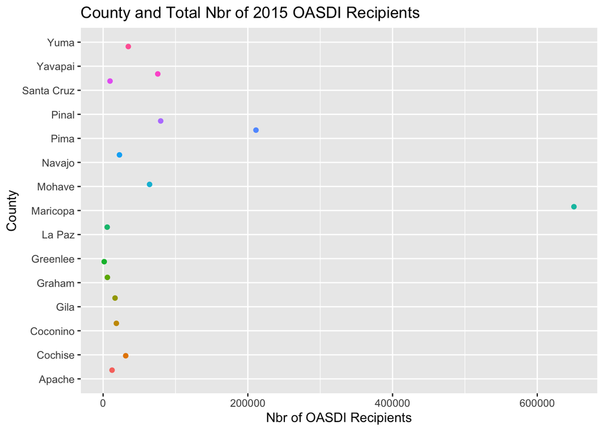

```r
library(ggplot2)

qplotgraph <- qplot(x = oasdiDataSummary$TotalNbr, y = oasdiDataSummary$`oasdiData$County`, data = oasdiDataSummary, color = factor(`oasdiData$County`), geom = "jitter") + geom_smooth(method = "lm", se = FALSE, color = "black") + labs(title = "County and Total Nbr of 2015 OASDI Recipients", x = "Nbr of OASDI Recipients", y = "County") + theme(legend.position = "none")
qplotgraph
```

The geom_qq graph that is used to determine whether a range of numbers follows a certain distribution. It looks like in the graph below, the Number of Retired Wokers recipients is not a perfect distribution and has several outliers. This also suggests the high outliers are due to more Retired Workers recipients live in Maricopa County. The other lines seem to have near perfect normal distribution.

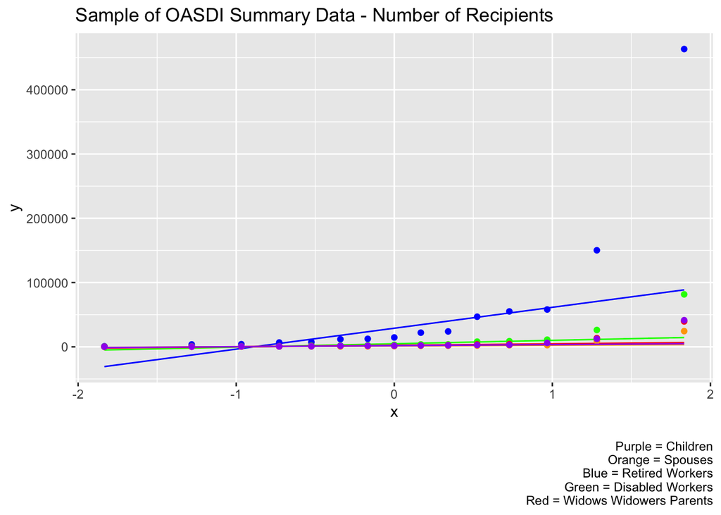

```r
ggplot(oasdiDataSummary, x = oasdiDataSummary$`oasdiData$County`, y = oasdiDataSummary$RetiredWorkersNbr) + geom_qq_line(aes(sample = oasdiDataSummary$RetiredWorkersNbr), color = "blue") + geom_qq(aes(sample = oasdiDataSummary$RetiredWorkersNbr), color = "blue") + geom_qq(aes(sample = oasdiDataSummary$DisabledWorkersNbr), color = "green") + geom_qq_line(aes(sample = oasdiDataSummary$DisabledWorkersNbr), color = "green")  + geom_qq(aes(sample = oasdiDataSummary$WidowsWidowersParentsNbr), color = "red") + geom_qq_line(aes(sample = oasdiDataSummary$WidowsWidowersParentsNbr), color = "red")  + geom_qq(aes(sample = oasdiDataSummary$SpousesNbr), color = "orange") + geom_qq_line(aes(sample = oasdiDataSummary$SpousesNbr), color = "orange")  + geom_qq(aes(sample = oasdiDataSummary$ChildrenNbr), color = "purple") + geom_qq_line(aes(sample = oasdiDataSummary$ChildrenNbr), color = "purple")  + labs(title = "Sample of OASDI Summary Data - Number of Recipients", caption = "\nPurple = Children\nOrange = Spouses\nBlue = Retired Workers\nGreen = Disabled Workers\nRed = Widows Widowers Parents")
```

The geom_qq graph below shows All Beneficiaries Total Monthly Benefits and Retired Workers Total Monthly Benefits have more outliers. The Widow(ers) and Parents Total Monthly Benefits has near perfect normal distribution.

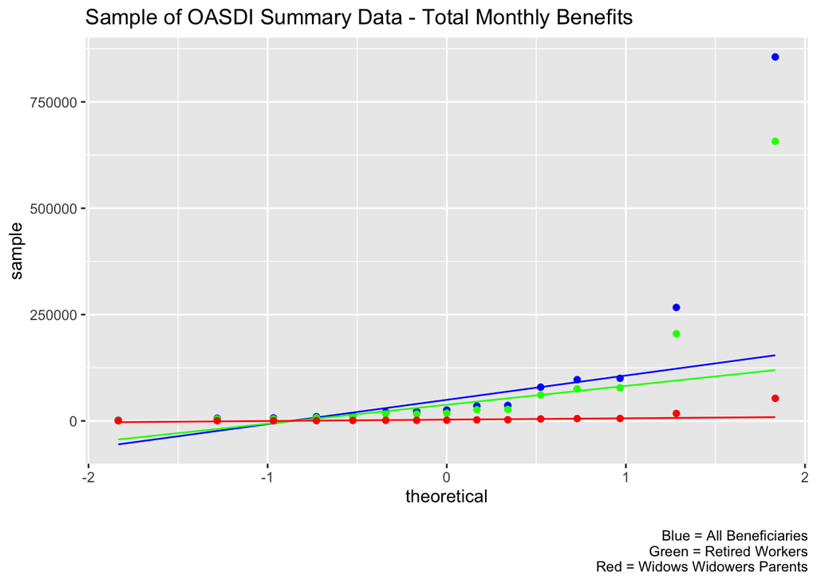

```r
ggplot(oasdiDataSummary, x = oasdiDataSummary$`oasdiData$County`, y = oasdiDataSummary$AllBeneficiariesTotMonthlyBenefits) + geom_qq(aes(sample = oasdiDataSummary$AllBeneficiariesTotMonthlyBenefits), color = "blue") + geom_qq_line(aes(sample = oasdiDataSummary$AllBeneficiariesTotMonthlyBenefits), color = "blue") + geom_qq(aes(sample = oasdiDataSummary$RetiredWorkersTotMonthlyBenefits), color = "green") + geom_qq_line(aes(sample = oasdiDataSummary$RetiredWorkersTotMonthlyBenefits), color = "green") + geom_qq(aes(sample = oasdiDataSummary$WidowsWidowersParentsTotMonthlyBenefits), color = "red") + geom_qq_line(aes(sample = oasdiDataSummary$WidowsWidowersParentsTotMonthlyBenefits), color = "red") + labs(title = "Sample of OASDI Summary Data - Total Monthly Benefits", caption = "\nBlue = All Beneficiaries\nGreen = Retired Workers\nRed = Widows Widowers Parents")
```

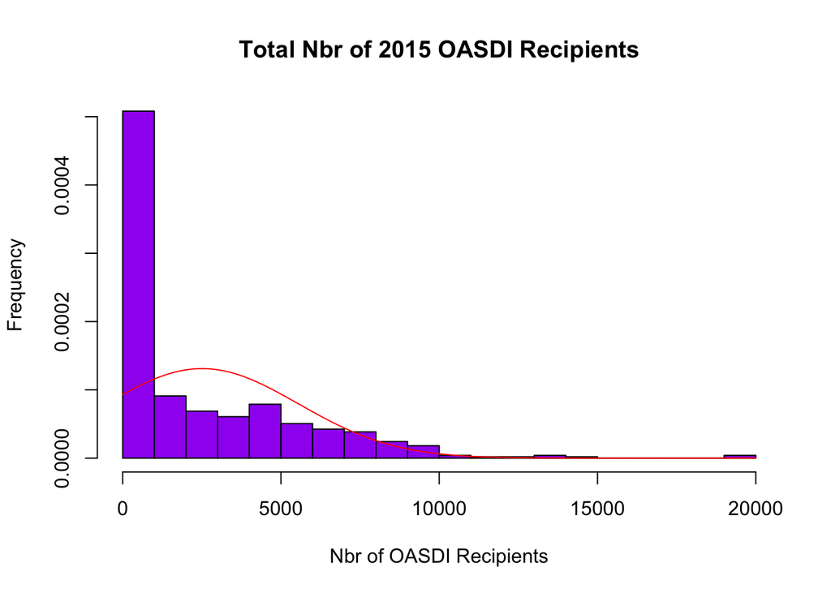

```r
hist(oasdiData$TotalNbr, col="purple", freq=FALSE, breaks="FD", main = "Total Nbr of 2015 OASDI Recipients", xlab = "Nbr of OASDI Recipients", ylab = "Frequency")
curve(dnorm(x, mean=mean(oasdiData$TotalNbr), sd=sd(oasdiData$TotalNbr)), add=TRUE, col="red")
```

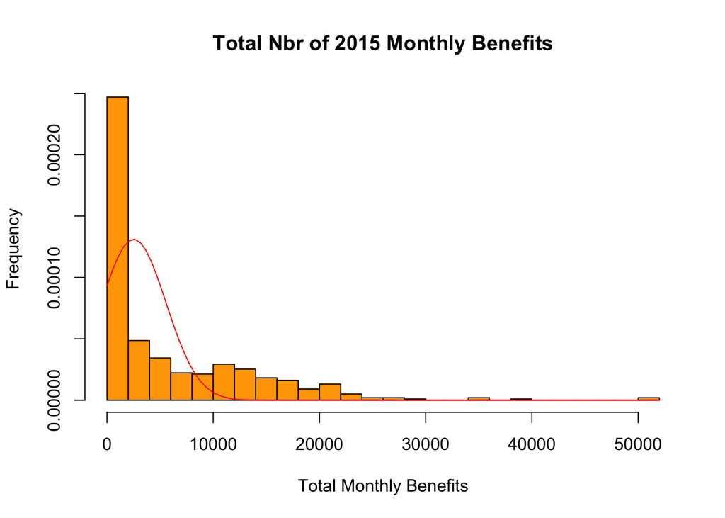

```r
hist(oasdiData$TotalMonthlyBenefits, col="orange", freq=FALSE, breaks="FD", main = "Total Nbr of 2015 Monthly Benefits", xlab = "Total Monthly Benefits", ylab = "Frequency")
curve(dnorm(x, mean=mean(oasdiData$TotalNbr), sd=sd(oasdiData$TotalNbr)), add=TRUE, col="red")
```

The scatter plot below shows most of the Total Nbr of recipients and Total Monthly Benefits based on ZIP code appear below 10,0000 recipients and 20,000 Monthly Benefits (in thousands). The outliers past that show certain ZIP codes (potentially in Maricopa County) that have a lot more recipients which will result in higher Total Monthly Benefits.

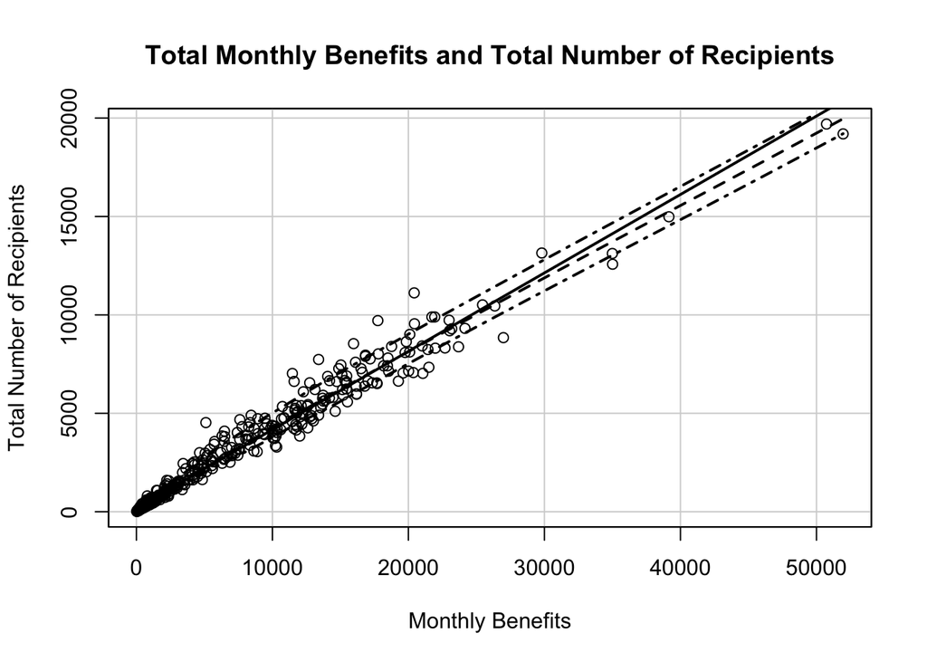

```r
scatterplot(oasdiData$TotalNbr~oasdiData$TotalMonthlyBenefits, boxplots= FALSE, col=gray(c(0,0.5,0.7)), data=oasdiDataSummary, main = "Total Monthly Benefits and Total Number of Recipients", xlab = "Monthly Benefits", ylab = "Total Number of Recipients")
```

The Scatter Plot Matrix is another way to show how each of the number of recipients relates to each other. The data is based on ZIP Codes.

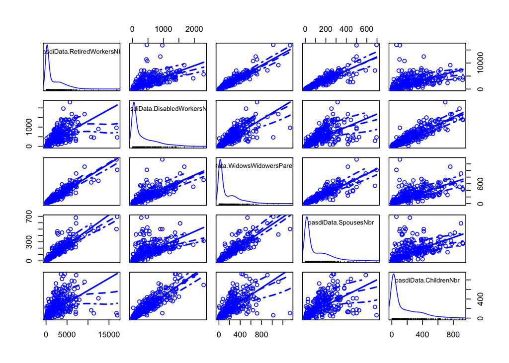

```r
scatterplotMatrix(~ oasdiData$RetiredWorkersNbr + oasdiData$DisabledWorkersNbr + oasdiData$WidowsWidowersParentsNbr + oasdiData$SpousesNbr + oasdiData$ChildrenNbr, data=oasdiData)
```

The Scatter Plot Matrix is another way to show how each of the Monthly Benefits relates to each other. The data is based on ZIP Codes.

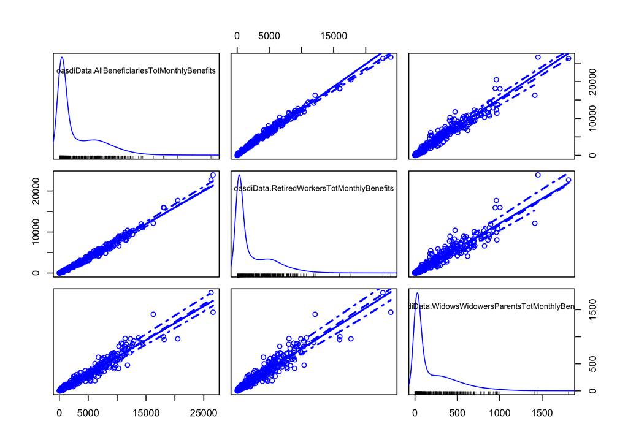

```r
scatterplotMatrix(~ oasdiData$AllBeneficiariesTotMonthlyBenefits + oasdiData$RetiredWorkersTotMonthlyBenefits + oasdiData$WidowsWidowersParentsTotMonthlyBenefits, data=oasdiData)
```

## Conclusion

Overall, depending on the groupings for the Total Number of recipient fields, the Top 5 varied a little by ZIP Code and City/Town. For instance, Sun City and Sun City West are in Maricopa County and are retirement communities. Surprise is just south of those communities so i would expect the number of total recipients to be high. Tucson (second populous city in Arizona) and Green Valley (suburb of Tucson) are in Pima County (near the border in the South Quadrants) have the 4th and 5th highest recipients.

The correlation between the Number of recipients and the Monthly Benefits (in thousands) seem to be greater when the population is higher. With Maricopa County being the most populous county and Pima County being the second most populous county, they will have more ZIP Codes that will be outliers compared to the rest of the state.

There were quite a few limitations that i ran into. The dataset was mainly based on two major categories, Number of Recipients and Monthly Benefits. There are only so many ways a person can slice and dice the data and look at it using graphs. Looking at the other states where the same data was gathered for would help compare information. A person would be able to gain better understanding of where the most people based on each category lived based on ZIP Code and County.

## Resources

Annual report providing Social Security beneficiary population data by state and ZIP code. Report for 2015.  
Source: https://catalog.data.gov/dataset/oasdi-beneficiaries-by-state-and-zip-code-2015 Last updated at https://catalog.data.gov/organization/ssa-gov : 2018-09-06